# Shootings across America in 2018

McCoy-Irick Palma

2/20/2020

## Summary

Shootings within the United States in 2018 occured all around the country, with a total of 340 shootings. The number of people killed in these shootings tally up to 373. The city to be most impacted by shootings, as in with the highest total of people killed and injured, was Chicago. Some other extrapolations from this data was that the month that had the most shootings out of all months (in abbreviation) was June, and that people were less likely to die (1.1) than be injured (3.96) within a shooting.

## Summary Table

Shooting Data by State in 2018

| state | Number of shootings | Number of people killed | Number of people injured | Total of people injured or killed | Avg killed per shooting | Average injured per shooting | Average injured or killed per shooting |
| --- | --- | --- | --- | --- | --- | --- | --- |
| Alabama | 14 | 12 | 55 | 67 | 0.86 | 3.93 | 4.79 |
| Arizona | 2 | 4 | 5 | 9 | 2.00 | 2.50 | 4.50 |
| Arkansas | 6 | 7 | 17 | 24 | 1.17 | 2.83 | 4.00 |
| California | 35 | 50 | 136 | 186 | 1.43 | 3.89 | 5.31 |
| Colorado | 8 | 9 | 27 | 36 | 1.12 | 3.38 | 4.50 |
| Connecticut | 2 | 0 | 8 | 8 | 0.00 | 4.00 | 4.00 |
| Delaware | 1 | 5 | 0 | 5 | 5.00 | 0.00 | 5.00 |
| District of Columbia | 6 | 2 | 23 | 25 | 0.33 | 3.83 | 4.17 |
| Florida | 30 | 48 | 132 | 180 | 1.60 | 4.40 | 6.00 |
| Georgia | 8 | 3 | 33 | 36 | 0.38 | 4.12 | 4.50 |
| Illinois | 35 | 21 | 150 | 171 | 0.60 | 4.29 | 4.89 |
| Indiana | 8 | 10 | 27 | 37 | 1.25 | 3.38 | 4.62 |
| Kansas | 2 | 1 | 11 | 12 | 0.50 | 5.50 | 6.00 |
| Kentucky | 4 | 7 | 25 | 32 | 1.75 | 6.25 | 8.00 |
| Louisiana | 13 | 15 | 50 | 65 | 1.15 | 3.85 | 5.00 |
| Maryland | 9 | 13 | 31 | 44 | 1.44 | 3.44 | 4.89 |
| Massachusetts | 1 | 0 | 4 | 4 | 0.00 | 4.00 | 4.00 |
| Michigan | 8 | 10 | 28 | 38 | 1.25 | 3.50 | 4.75 |
| Minnesota | 3 | 1 | 14 | 15 | 0.33 | 4.67 | 5.00 |
| Mississippi | 3 | 1 | 17 | 18 | 0.33 | 5.67 | 6.00 |
| Missouri | 14 | 12 | 52 | 64 | 0.86 | 3.71 | 4.57 |
| Nebraska | 3 | 1 | 16 | 17 | 0.33 | 5.33 | 5.67 |
| Nevada | 4 | 3 | 15 | 18 | 0.75 | 3.75 | 4.50 |
| New Jersey | 10 | 4 | 54 | 58 | 0.40 | 5.40 | 5.80 |
| New Mexico | 2 | 5 | 4 | 9 | 2.50 | 2.00 | 4.50 |
| New York | 13 | 5 | 53 | 58 | 0.38 | 4.08 | 4.46 |
| North Carolina | 11 | 14 | 37 | 51 | 1.27 | 3.36 | 4.64 |
| Ohio | 11 | 13 | 46 | 59 | 1.18 | 4.18 | 5.36 |
| Oklahoma | 5 | 2 | 19 | 21 | 0.40 | 3.80 | 4.20 |
| Pennsylvania | 19 | 35 | 63 | 98 | 1.84 | 3.32 | 5.16 |
| South Carolina | 4 | 5 | 19 | 24 | 1.25 | 4.75 | 6.00 |
| Tennessee | 18 | 19 | 68 | 87 | 1.06 | 3.78 | 4.83 |
| Texas | 16 | 29 | 62 | 91 | 1.81 | 3.88 | 5.69 |
| Utah | 1 | 0 | 4 | 4 | 0.00 | 4.00 | 4.00 |
| Virginia | 4 | 2 | 17 | 19 | 0.50 | 4.25 | 4.75 |
| Washington | 3 | 4 | 9 | 13 | 1.33 | 3.00 | 4.33 |
| Wisconsin | 4 | 1 | 16 | 17 | 0.25 | 4.00 | 4.25 |

## Summary Table Insights

A couple insights we can derive from this table are that the states with the highest amount of shootings are California and Illinois, with California having more people killed whereas Illinois had more people injured in shootings. As for state averages, the states with the highest people killed were Arizona, Delaware, and New Mexico. However, this is mainly due to these states having 1-2 shootings recorded. The same can be said about the averages for amount of people injured and total people involved, as states with lower sample sizes typically were amongst the highest averages.

## Case Study: Parkland Shooting

The shooting with the most killed and injured happened on February 14, 2018 in Pompano Beach (Parkland), Florida at Stoneman Douglas High School. The amount of people killed in the shooting was 17 with also another 17 injured. Not only was this the most deadly mass shooting of 2018, it was one of the most deadliest in all of America’s history ([source](https://www.nbcnews.com/news/us-news/police-respond-shooting-parkland-florida-high-school-n848101)). Beyond the shooting, the death toll due to the effects (mental, physical) of the shooting have surpassed the original 17 mark as some of the survivors have passed away since it took place. This event in particular sparked many youth political policy campaigns for gun reform in response to mass gun violence in the country.

## Shootings across America in 2018: Interactive Map

This map shows every individual shooting as a circle with its radius depending on the total amount of people killed and injured per shooting. With that, the more red a circle is, means that there’s a higher density of shootings in that area. You can then compare shootings by total amount of people injured and killed based on the characteristics of each circle, as well as comparisons for density for different locations across the United States.

[interactive chart not shown]

## Interactive Map Insights

A couple of insights to be found within the interactive map is that there appears to be a more significant amount of shootings happening in the Eastern side of the United States if you were geographically split the country and that the biggest of shootings were usually centered in cities that already have a prevalence in shootings.

## Shootings by Month

One of the questions I had was what month had the most shootings in 2018 which I felt was best represented in a bar-chart because of the clarity and simplicity that can communicated for one numerical variable (frequency) and one categorical variable (month) without the need to show individual characteristics for each data point (opposed to stacked, standardized bar-plots).

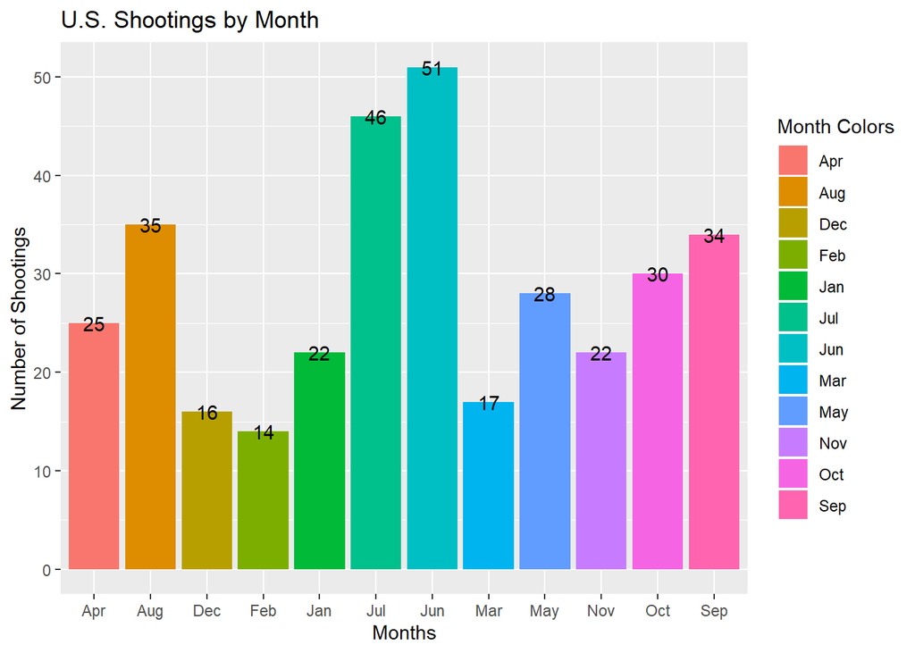

## Shootings by Month Insights

One of the most interesting that can be found within the chart is that not only is June the month with the most amount of shootings, the whole season of summer is has the highest amount of shootings out of the whole year. As the year progresses to spring and summer and regresses to fall and winter, so does the amount of shootings with June, July, and August, all of the months of summer which also have the highest amounts of shootings for all the months. Another insight is that the month with the lowest amount of shootings was February, with December and March following close behind which can be seen as the winter and spring having the lowest amounts of shootings out of the seasons.